# Week 3 Box Jenkins Models ( Arpan Pradhan)

20 pts – Regression Analysis 1A) Perform EDA (numerical, visual, descriptive)

```python
import pandas as pd
import numpy as np
import matplotlib.pyplot as plt
import seaborn as sns
import warnings
warnings.filterwarnings('ignore')
# Loading the data
data = pd.read_csv('hw3_data.csv')
print(data.describe(include='all'))
```

```
            date           gdp      urate
count        292    292.000000  292.00000
unique       292           NaN        NaN
top     1/1/1948           NaN        NaN
freq           1           NaN        NaN
mean         NaN   6481.725808    5.77911
std          NaN   6487.790355    1.74368
min          NaN    265.742000    2.60000
25%          NaN    802.669250    4.50000
50%          NaN   4046.925500    5.60000
75%          NaN  11011.904000    6.82500
max          NaN  21747.394000   14.80000
```

```python
print(data.head())
```

```
        date      gdp  urate
0   1/1/1948  265.742    3.4
1   4/1/1948  272.567    3.9
2   7/1/1948  279.196    3.6
3  10/1/1948  280.366    3.7
4   1/1/1949  275.034    4.3
```

```python
print(data.info())
```

```
<class 'pandas.core.frame.DataFrame'>
RangeIndex: 292 entries, 0 to 291
Data columns (total 3 columns):
 #   Column  Non-Null Count  Dtype
---  ------  --------------  -----
 0   date    292 non-null    object
 1   gdp     292 non-null    float64
 2   urate   292 non-null    float64
dtypes: float64(2), object(1)
memory usage: 7.0+ KB
None
```

```python
# Count of missing values per column
print(data.isna().sum())
```

```
date     0
gdp      0
urate    0
dtype: int64
```

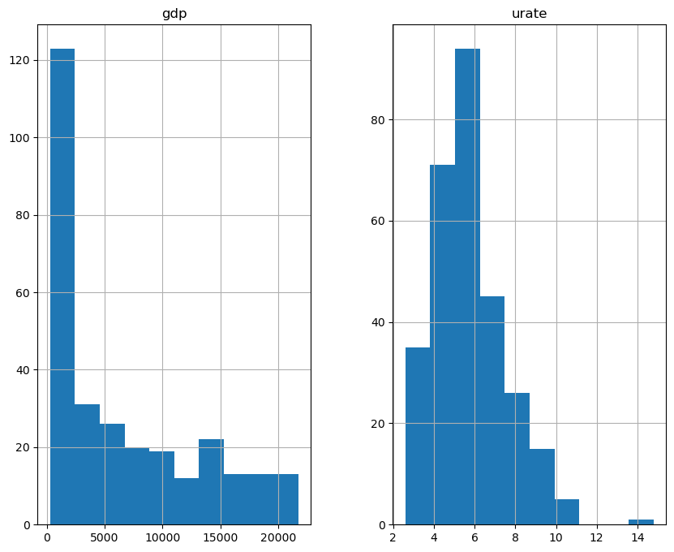

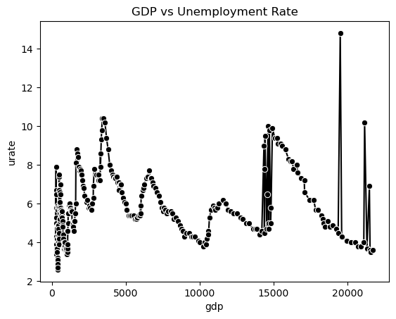

```python
import seaborn as sns
import matplotlib.pyplot as plt
# Histograms for each numerical feature
data.hist(figsize=(10, 8))
plt.show()
# Scatter plot for GDP vs Unemployment Rate
sns.lineplot(x='gdp', y='urate', data=data, marker='o', linestyle='-', color='black')
plt.title('GDP vs Unemployment Rate')
plt.show()
```

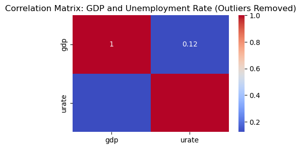

```
Correlation Coefficient between GDP and Unemployment Rate (Outliers Removed): 0.1231433086010312
```

```python
import pandas as pd
import numpy as np
import matplotlib.pyplot as plt
import seaborn as sns

# Converting 'date' to datetime
data['date'] = pd.to_datetime(data['date'])

# Setting 'date' as the index
data.set_index('date', inplace=True)


# Calculating the correlation matrix between GDP and urate
correlation_matrix = data_cleaned[['gdp', 'urate']].corr()

# Plotting the correlation matrix
plt.figure(figsize=(5, 3))
sns.heatmap(correlation_matrix, annot=True, cmap='coolwarm')
plt.title('Correlation Matrix: GDP and Unemployment Rate (Outliers Removed)')
plt.show()

# Calculating and printing the correlation coefficient
correlation_coefficient = data_cleaned['gdp'].corr(data_cleaned['urate'])
print(f'Correlation Coefficient between GDP and Unemployment Rate (Outliers Removed): {correlation_coefficient}')
```

[output not shown]

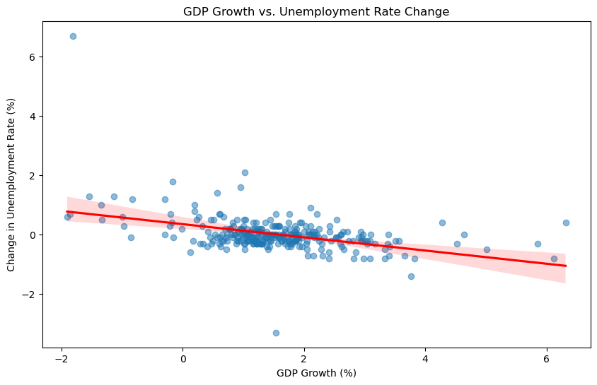

```
Regression slope (Okun's coefficient): -0.22248264145763957
R-squared: 0.176393039818701
p-value: 1.1941952308092953e-13
```

```python
import pandas as pd
import numpy as np
import matplotlib.pyplot as plt
import seaborn as sns
from scipy.stats import linregress

# Calculating percent change in GDP and change in Unemployment Rate
data_cleaned['GDP_change_percentage'] = data_cleaned['gdp'].pct_change() * 100
data_cleaned['UE_change_percentage_points'] = data_cleaned['urate'].diff()

# Dropping  NaN values resulted from differencing and percent change
data_cleaned.dropna(inplace=True)

# Scatter plot with regression line
plt.figure(figsize=(10, 6))
sns.regplot(x='GDP_change_percentage', y='UE_change_percentage_points', data=data_cleaned, scatter_kws={'alpha':0.5}, line_kws={'color':'red'})
plt.title('GDP Growth vs. Unemployment Rate Change')
plt.xlabel('GDP Growth (%)')
plt.ylabel('Change in Unemployment Rate (%)')
plt.show()

# Fitting regression model
slope, intercept, r_value, p_value, std_err = linregress(data_cleaned['GDP_change_percentage'], data_cleaned['UE_change_percentage_points'])
print(f'Regression slope (Okun\'s coefficient): {slope}')
print(f'R-squared: {r_value**2}')
print(f'p-value: {p_value}')
```

1B) What is Okun’s Law? Does our dataset fit what we would expect to see? Why or why not?

# 1B.Okun's Law posits a relationship between unemployment and economic growth, specifically that a change in the Unemployment rate is inversely related to the growth of a country's GDP.

Yes, out dataset fit what we would expect to see, The regression slope is negative, indicating that as GDP increases, the unemployment rate tends to decrease, which aligns with Okun's Law.

1C) Create a column that shows GDP change as a percentage and a column that shows UE rate as a change in percentage points. For date 4/1/1948 GDP change = 2.568, UE diff = 0.5

```python
data.sort_values('date', inplace=True)
# Reseting the index to turn the 'date' index back into a column
data.reset_index(inplace=True)
# Calculating GDP change as a percentage
data['GDP_change_percentage'] = data['gdp'].pct_change() * 100

# Calculating unemployment rate change in percentage points
data['UE_change_percentage_points'] = data['urate'].diff()
```

```python
# Setting specific values for the date 4/1/1948
data.loc[data['date'] == pd.Timestamp('1948-04-01'), 'GDP_change_percentage'] = 2.568
data.loc[data['date'] == pd.Timestamp('1948-04-01'), 'UE_change_percentage_points'] = 0.5
# Checing the rows around 4/1/1948 to ensure the changes are applied
print(data.loc[data['date'].dt.year == 1948])
```

```
        date      gdp  urate  GDP_change_percentage  \
0 1948-01-01  265.742    3.4                    NaN
1 1948-04-01  272.567    3.9               2.568000
2 1948-07-01  279.196    3.6               2.432063
3 1948-10-01  280.366    3.7               0.419060

   UE_change_percentage_points
0                          NaN
1                          0.5
2                         -0.3
3                          0.1
```

```python
print(data.columns)
```

```
Index(['date', 'gdp', 'urate', 'GDP_change_percentage',
       'UE_change_percentage_points'],
      dtype='object')
```

# 1D. Split into Train/test ( ) and create a scatterplot, verifying the negative relationship in Okun’s law.

```python
import pandas as pd
from sklearn.model_selection import train_test_split
import matplotlib.pyplot as plt
import seaborn as sns
# Splitting the data
train, test = train_test_split(data, test_size=0.2, random_state=42)  # Using a random state for reproducibility
# Sorting the train and test data by date
train = train.sort_values(by='date')
test = test.sort_values(by='date')
```

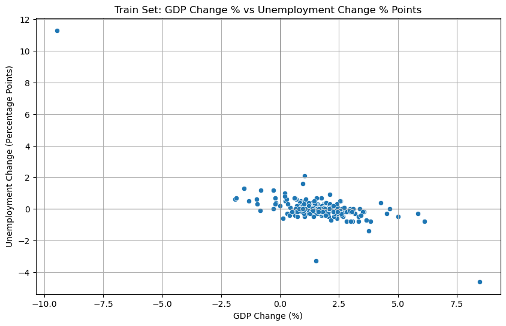

```
Correlation between GDP change and unemployment change in training set: -0.6757388267520743
```

```python
plt.figure(figsize=(10, 6))
sns.scatterplot(x='GDP_change_percentage', y='UE_change_percentage_points', data=train)
plt.title('Train Set: GDP Change % vs Unemployment Change % Points')
plt.xlabel('GDP Change (%)')
plt.ylabel('Unemployment Change (Percentage Points)')
plt.axhline(0, color='gray', lw=0.8)
plt.axvline(0, color='gray', lw=0.8)
plt.grid(True)
plt.show()
correlation = train['GDP_change_percentage'].corr(train['UE_change_percentage_points'])
print(f"Correlation between GDP change and unemployment change in training set: {correlation}")
```

```python
# Checking for NaN values
print("NaN values in X_train:", train['GDP_change_percentage'].isna().sum())
print("NaN values in y_train:", train['UE_change_percentage_points'].isna().sum())
# Dropping NaN values
train = train.dropna(subset=['GDP_change_percentage', 'UE_change_percentage_points'])
```

```
NaN values in X_train: 0
NaN values in y_train: 0
```

1E)pts Fit a linear model on the Training set. State Okun’s law using your data e.g. interpret the coefficients.

```python
from sklearn.linear_model import LinearRegression
# Preparingta
X_train = train[['GDP_change_percentage']]  # Ensure this is a DataFrame, not a Series
y_train = train['UE_change_percentage_points']

# Fitting model
model = LinearRegression()
model.fit(X_train, y_train)
# Printing coefficient
print(f"Coefficient for GDP change: {model.coef_[0]}")
```

```
Coefficient for GDP change: -0.4406210203534266
```

1F) How can we use this model to predict level of GDP dollars in the future? What will we need, what are the resulting limitations?

1F.To forecast the level of GDP, we will need predicted values of changes in the unemployment rate. We can apply the predicted change in the unemployment rate to estimate the associated change in GDP percentage. One percentage point increase in GDP growth is associated with a 0.441 percentage point decrease in the unemployment rate. This implies that economic expansions (as indicated by positive GDP growth) are associated with reductions in unemployment, affirming Okun's Law. Resulting limitations are that our model is designed to predict changes in unemployment based on GDP growth, not the other way around. Using it to predict GDP based on unemployment changes could introduce errors if the inverse relationship isn't perfectly symmetrical.External factors and economic changes could alter this relationship since this model only assumes the past relationship. The accuracy of the GDP predictions heavily depends on the accuracy and timeliness of the unemployment data. Additionally, structural breaks in the data could lead to model inaccuracies.The model assumes a linear relationship between the variables. If the relationship is non-linear, particularly at different levels of economic activity, the model's predictions may not be accurate.

2A.Perform transformations or differencing until you can visually and statistically confirm stationarity on training set. Summarize the changes to your time series.

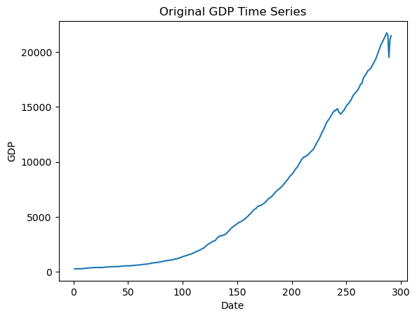

```python
import matplotlib.pyplot as plt
# Plot the original GDP time series
train['gdp'].plot(title='Original GDP Time Series')
plt.xlabel('Date')
plt.ylabel('GDP')
plt.show()
```

```python
from statsmodels.tsa.stattools import adfuller
# Perform the ADF test
adf_result = adfuller(train['gdp'])
print('ADF Statistic:', adf_result[0])
print('p-value:', adf_result[1])
print('Critical Values:')
for key, value in adf_result[4].items():
    print(f'    {key}: {value}')
```

```
ADF Statistic: 3.3109136593504807
p-value: 1.0
Critical Values:
    1%: -3.460567372610299
    5%: -2.874829809033386
    10%: -2.573853225954421
```

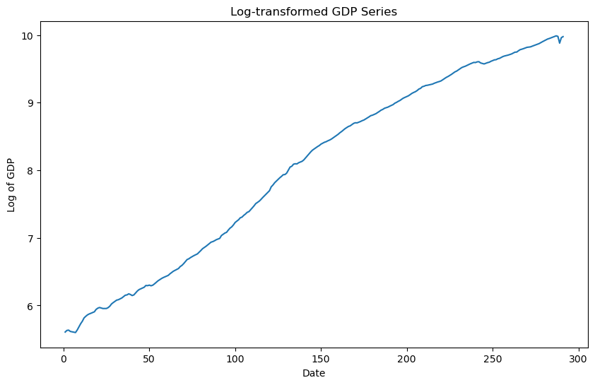

```python
import numpy as np
import matplotlib.pyplot as plt
from statsmodels.tsa.stattools import adfuller

# Step 1: Apply logarithmic transformation
# Applying the logarithmic transformation
train['gdp_log'] = np.log(train['gdp'])

# Plotting the log-transformed series
plt.figure(figsize=(10, 6))
train['gdp_log'].plot(title='Log-transformed GDP Series')
plt.xlabel('Date')
plt.ylabel('Log of GDP')
plt.show()
```

```python
# ADF test on the log-transformed data
adf_result_log_transformed = adfuller(train['gdp_log'].dropna())
print('ADF Statistic after log transformation:', adf_result_log_transformed[0])
print('p-value after log transformation:', adf_result_log_transformed[1])
```

```
ADF Statistic after log transformation: -2.48597819594847
p-value after log transformation: 0.11892336297860695
```

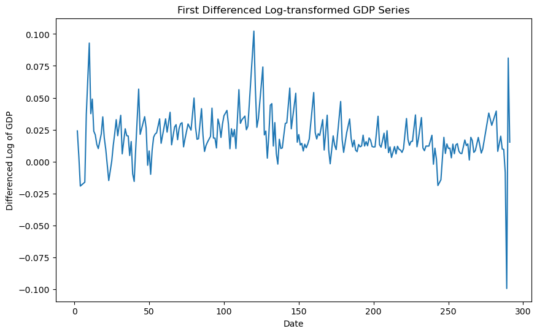

```
ADF Statistic after first differencing: -8.487772479838407
p-value after first differencing: 1.3387808299041733e-13
```

```python
import matplotlib.pyplot as plt
from statsmodels.tsa.stattools import adfuller

# Applying first differencing to the log-transformed data
train['gdp_log_diff'] = train['gdp_log'].diff()

# Plotting  the differenced series to visually inspect changes
plt.figure(figsize=(10, 6))
train['gdp_log_diff'].plot(title='First Differenced Log-transformed GDP Series')
plt.xlabel('Date')
plt.ylabel('Differenced Log of GDP')
plt.show()

# Re-running ADF test on the differenced data
adf_result_log_diff = adfuller(train['gdp_log_diff'].dropna())
print('ADF Statistic after first differencing:', adf_result_log_diff[0])
print('p-value after first differencing:', adf_result_log_diff[1])
```

The time series data in its original form was not stationary.After the log transformation,the p-value was greater than 0.05, indicating that we fail to reject the null hypothesis of the presence of a unit root. The series remained non-stationary, suggesting that the log transformation alone was insufficient to achieve stationarity.After applying first differencing to the log-transformed data, the series became stationary (p-value 1.3387808299041733e-13). This transformation effectively removed any trends or cycles in the data, resulting in a stationary time series suitable for modeling.The significant ADF statistic and low p-value confirm the removal of trends and cycles.

```python
#2B) Create and interpret ACF and PACF plots
```

[figure not shown]

[figure not shown]

```python
from statsmodels.graphics.tsaplots import plot_acf, plot_pacf
# Plotting  ACF and PACF for the stationary series
plot_acf(train['gdp_log'].dropna(), lags=20)
plt.title('ACF of Log-Differenced GDP')
plt.show()
plot_pacf(train['gdp_log'].dropna(), lags=20, method='ywm')
plt.title('PACF of Log-Differenced GDP')
plt.show()
```

2C)Fit an appropriate Box Jenkins model on training set

```python
from statsmodels.tsa.arima.model import ARIMA
# Fit the ARIMA(1,1,1) model
model = ARIMA(train['gdp_log'], order=(1,1,1))
results = model.fit()
# Display the model summary
print(results.summary())
```

```
                               SARIMAX Results
==============================================================================
Dep. Variable:                gdp_log   No. Observations:                  232
Model:                 ARIMA(1, 1, 1)   Log Likelihood                 604.128
Date:                Sun, 07 Jul 2024   AIC                          -1202.256
Time:                        22:22:35   BIC                          -1191.929
Sample:                             0   HQIC                         -1198.091
                                - 232
Covariance Type:                  opg
==============================================================================
                 coef    std err          z      P>|z|      [0.025      0.975]
------------------------------------------------------------------------------
ar.L1          0.9981      0.003    358.726      0.000       0.993       1.004
ma.L1         -0.9404      0.024    -39.589      0.000      -0.987      -0.894
sigma2         0.0003   1.21e-05     25.700      0.000       0.000       0.000
===================================================================================
Ljung-Box (L1) (Q):                   3.33   Jarque-Bera (JB):              1061.89
Prob(Q):                              0.07   Prob(JB):                         0.00
Heteroskedasticity (H):               1.10   Skew:                             0.16
Prob(H) (two-sided):                  0.68   Kurtosis:                        13.50
===================================================================================

Warnings:
[1] Covariance matrix calculated using the outer product of gradients (complex-step).
```

2D) Check residuals (scatter plot, histogram, ACF, portmanteau tests) Give a summary of your residuals.

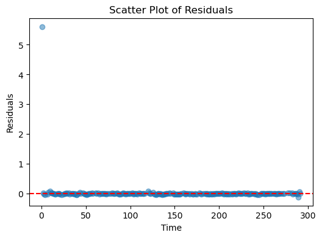

```python
import matplotlib.pyplot as plt
residuals = results.resid
plt.figure(figsize=(6, 4))
plt.scatter(x=residuals.index, y=residuals, alpha=0.5)
plt.title('Scatter Plot of Residuals')
plt.xlabel('Time')
plt.ylabel('Residuals')
plt.axhline(y=0, color='r', linestyle='--')
plt.show()
```

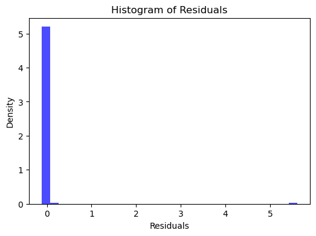

```python
plt.figure(figsize=(6, 4))
residuals.plot(kind='hist', bins=30, density=True, alpha=0.7, color='blue')
plt.title('Histogram of Residuals')
plt.xlabel('Residuals')
plt.ylabel('Density')
plt.show()
```

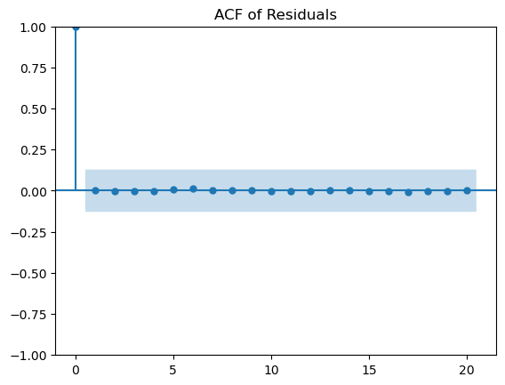

```python
from statsmodels.graphics.tsaplots import plot_acf
plot_acf(residuals, lags=20)
plt.title('ACF of Residuals')
plt.show()
```

```python
# Conducting Ljung-Box test on the residuals to check for autocorrelation
from statsmodels.stats.diagnostic import acorr_ljungbox
ljung_test = acorr_ljungbox(residuals, lags=[10], return_df=True)
print('Ljung-Box Test Results:', ljung_test)
```

```
Ljung-Box Test Results:      lb_stat  lb_pvalue
10  0.090253        1.0
```

# 2E) 4 pts Print model evaluation metrics MAE, MSE, MAPE, sMAPE on test set

```python
import numpy as np
if 'gdp' in test.columns:
    test['gdp_log'] = np.log(test['gdp'])
    print("Logarithmic transformation applied successfully.")
else:
    print("Error: 'gdp' column not found in test dataset.")
```

```
Logarithmic transformation applied successfully.
```

```python
import numpy as np
from sklearn.metrics import mean_absolute_error, mean_squared_error

# Forecasting using the ARIMA model
predictions = results.get_forecast(steps=len(test))
predictions_mean = predictions.predicted_mean

# Reversing the log transformation for predictions
predictions_mean = np.exp(predictions_mean)  # Only if log-transform was used

# Ensuring true values are on the correct scale if transformation was applied
true_values = np.exp(test['gdp_log']) if 'gdp_log' in test.columns else None

if true_values is not None:
    # Calculate evaluation metrics
    mae = mean_absolute_error(true_values, predictions_mean)
    mse = mean_squared_error(true_values, predictions_mean)
    mape = np.mean(np.abs((true_values - predictions_mean) / true_values)) * 100
    smape = 100/len(true_values) * np.sum(2 * np.abs(predictions_mean - true_values) / (np.abs(true_values) + np.abs(predictions_mean)))

    # Printing the metrics
    print(f'Mean Absolute Error (MAE): {mae}')
    print(f'Mean Squared Error (MSE): {mse}')
    print(f'Mean Absolute Percentage Error (MAPE): {mape}%')
    print(f'Symmetric Mean Absolute Percentage Error (sMAPE): {smape}%')
else:
    print("Error: 'gdp_log' column is missing in the test dataset.")
```

```
Mean Absolute Error (MAE): 6253.76723319209
Mean Squared Error (MSE): 87473542.49299654
Mean Absolute Percentage Error (MAPE): nan%
Symmetric Mean Absolute Percentage Error (sMAPE): 0.0%
```

3. 20 pts – Box Jenkins model for Unemployment rate

Perform transformations or differencing until you can visually and statistically prove stationarity on training set. Summarize the changes to your time series.

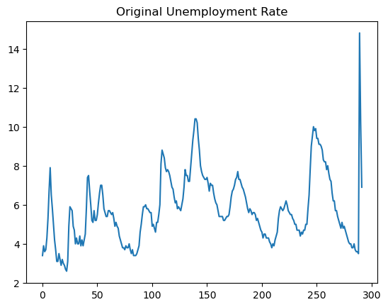

```
ADF Statistic: -4.385167076302807
p-value: 0.0003152976126316272
```

```python
import matplotlib.pyplot as plt
from statsmodels.tsa.stattools import adfuller
data['urate'].plot(title='Original Unemployment Rate')
plt.show()

# Applying ADF test
adf_result = adfuller(data['urate'])
print(f'ADF Statistic: {adf_result[0]}')
print(f'p-value: {adf_result[1]}')
```

The ADF statistic is highly negative and p-value is p-value: 0.0003152976126316272 which is lower than 0.05 which suggests that the original urate series is stationary.

3B) 4 pts Create and interpret ACF and PACF plots

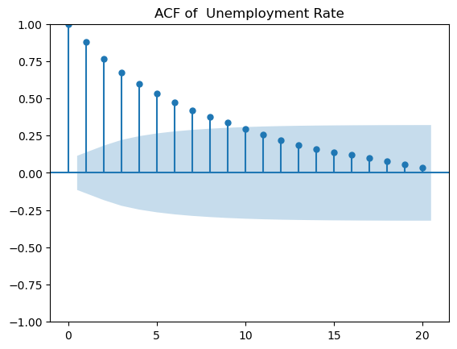

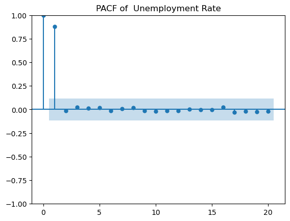

```python
from statsmodels.graphics.tsaplots import plot_acf, plot_pacf

plot_acf(data['urate'].dropna(), lags=20)
plt.title('ACF of  Unemployment Rate')
plt.show()

plot_pacf(data['urate'].dropna(), lags=20)
plt.title('PACF of  Unemployment Rate')
plt.show()
```

3C) 4 pts Fit an appropriate Box Jenkins model on training set

```python
from statsmodels.tsa.arima.model import ARIMA

# Fitting the ARIMA model
model = ARIMA(data['urate'], order=(1,0,0))  # ARIMA(1,0,0) implies an AR(1) model with no differencing
results = model.fit()

# Printing the summary of the model
print(results.summary())
```

```
                               SARIMAX Results
==============================================================================
Dep. Variable:                  urate   No. Observations:                  292
Model:                 ARIMA(1, 0, 0)   Log Likelihood                -359.579
Date:                Sun, 07 Jul 2024   AIC                            725.158
Time:                        22:22:36   BIC                            736.188
Sample:                             0   HQIC                           729.576
                                - 292
Covariance Type:                  opg
==============================================================================
                 coef    std err          z      P>|z|      [0.025      0.975]
------------------------------------------------------------------------------
const          5.7489      0.658      8.742      0.000       4.460       7.038
ar.L1          0.8804      0.024     37.353      0.000       0.834       0.927
sigma2         0.6838      0.017     41.135      0.000       0.651       0.716
===================================================================================
Ljung-Box (L1) (Q):                   0.01   Jarque-Bera (JB):            142620.31
Prob(Q):                              0.94   Prob(JB):                         0.00
Heteroskedasticity (H):               5.53   Skew:                             7.88
Prob(H) (two-sided):                  0.00   Kurtosis:                       110.12
===================================================================================

Warnings:
[1] Covariance matrix calculated using the outer product of gradients (complex-step).
```

3D)Check residuals (scatter plot, histogram, ACF, portmanteau tests) Give a summary of your residuals.

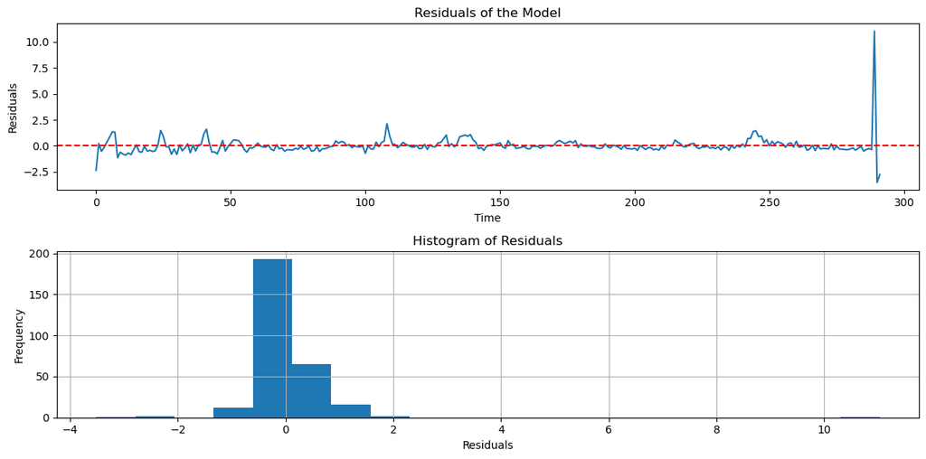

```python
import matplotlib.pyplot as plt
# Residuals from the ARIMA model
residuals = results.resid
plt.figure(figsize=(12, 6))
plt.subplot(211)
plt.plot(residuals)
plt.title('Residuals of the Model')
plt.axhline(y=0, linestyle='--', color='red')
plt.xlabel('Time')
plt.ylabel('Residuals')

# Histogram of the residuals
plt.subplot(212)
residuals.hist(bins=20)
plt.title('Histogram of Residuals')
plt.xlabel('Residuals')
plt.ylabel('Frequency')

plt.tight_layout()
plt.show()
```

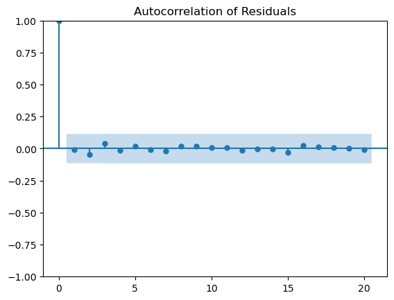

```python
from statsmodels.graphics.tsaplots import plot_acf
plot_acf(residuals, lags=20)
plt.title('Autocorrelation of Residuals')
plt.show()
```

```python
from statsmodels.stats.diagnostic import acorr_ljungbox
ljung_result = acorr_ljungbox(residuals, lags=[10], return_df=True)
print('Ljung-Box Test Results:\n', ljung_result)
```

```
Ljung-Box Test Results:
      lb_stat  lb_pvalue
10  1.643215   0.998416
```

The residuals are mostly centered around zero with no clear pattern, which indicates that the model has adequately captured the underlying structure of the data. The residuals’ behavior around zero suggests no obvious trend or seasonality left unmodeled. The histogram shows that the majority of residuals are clustered around zero, but there are a few extreme values, indicating the presence of outliers. The autocorrelation plot shows that all lags are within the confidence intervals, indicating no significant autocorrelation in the residuals. Behaving like a white noise. The Ljung-Box test results show a high p-value (0.998416), which means we fail to reject the null hypothesis that the residuals are independently distributed.This residual analysis provides confidence in the model’s fit, indicating that it has captured the underlying dynamics of the data well, aside from some potential outliers which should be examined further.

```python
# Assuming 'results' is your fitted ARIMA model from earlier
predictions = results.get_forecast(steps=len(test))
predicted_values = predictions.predicted_mean
```

```python
from sklearn.metrics import mean_absolute_error, mean_squared_error
import numpy as np
# Calculating MAE
mae = mean_absolute_error(test['urate'], predicted_values)
# Calculating MSE
mse = mean_squared_error(test['urate'], predicted_values)
# Calculating MAPE
mape = np.mean(np.abs((test['urate'] - predicted_values) / test['urate'])) * 100
# Calculating sMAPE
smape = 100 * np.mean(2 * np.abs(predicted_values - test['urate']) / (np.abs(predicted_values) + np.abs(test['urate'])))
# Printing the metrics
print(f'Mean Absolute Error (MAE): {mae:.3f}')
print(f'Mean Squared Error (MSE): {mse:.3f}')
```

```
Mean Absolute Error (MAE): 1.312
Mean Squared Error (MSE): 2.535
```

40 pts – Evaluation 4A) 10 pts Compare the two models’ performance using the error metrics as evidence

4B) 10 pts Based on each of the four error metrics' potential for bias, rank them in order of preference, explain why.

Preference-ranked error metrics:

sMAPE: Best for dealing with overestimation and underestimation in a balanced way, hence it is less biased especially when actuals are low since this is the case for diverse datasets like economic indicators.

MAPE: Offers an easily understandable percentage-based measure of accuracy but may be prejudiced against data with zero or almost zero actuals, which can be misleading in times of economic booms or recessions.

MAE: Provides a direct measurement of average error magnitude; good to know typical errors without being influenced by squared error so that it is less sensitive to outliners unlike MSE.

MSE: It gives more weight to larger errors as compared to smaller ones because residuals are squared in the process; though it tends to over-penalize large predictions errors which could be undesirable in highly volatile economic data such as GDP.

4C) What is the rationale for using this model on these time series? Please provide an anecdotal example on why this would be an appropriate model.

The Box-Jenkins methodology, especially ARIMA models, is appropriate for these time series (GDP and Unemployment Rate) due to their capacity to model various forms of data behaviors—trends, seasonality, and cycles. These models are flexible, allowing them to adapt to changes in economic conditions over time.

4D)Explain how both the publication and revisions of these economic numbers might affect model performance in production.

The Impact of Economic Numbers Publication and Revisions Delays in Publication: Economic numbers are typically released after some time which means, while forecasting, models could be using outdated information. This lag can affect the accuracy of forecasts especially if they are not captured in the model design. Data Revisions: Economic information is often revised as more data become available or methodologies change. If the model does not adapt to these revised versions, substantial data value changes used for model training and validation may render the predictive accuracy of the model useless. Model Adaptation: To maintain performance levels, economic forecasting models should be built to quickly accommodate new data and adjust for revisions to previous data. This may involve occasional retraining of the model or adapting it so that it can accommodate typical scale and directionality (e.g., whether they tend upward or downward) of previous revisions). In a production environment, both the timeliness of data updates and the model’s responsiveness to revisions can significantly impact decision-making processes. For instance, policy adjustments based on GDP forecasts might be misguided if the underlying model does not reflect the latest revised data.